# The Life of a Showgirl: something new

Jean Clipperton

2025-10-04

## Dancing through the lightning strikes: Life of a Showgirl is something new

I build on analyses done in our article [You do not get to tell me about Sad: Swiftian Saudade in Taylor Swift’s Lyrics](https://psycnet.apa.org/record/2026-72031-001) to incorporate Taylor Swift’s latest release, *The Life of a Showgirl.* The data is the same from that article, with the addition of Swift’s newest relase, copied from Genius.com. These are preliminary results (data collected at 12:01 am 10/3 on the release date) and based on preliminary lyrics – there may be typos or incorrect components.

Further note that I wrote this in the same time period as the release. It’s an evolving work in progress!

### Joyful and emotion-laden

In some ways, it is similar to her prior work: there is a lot of joy present.

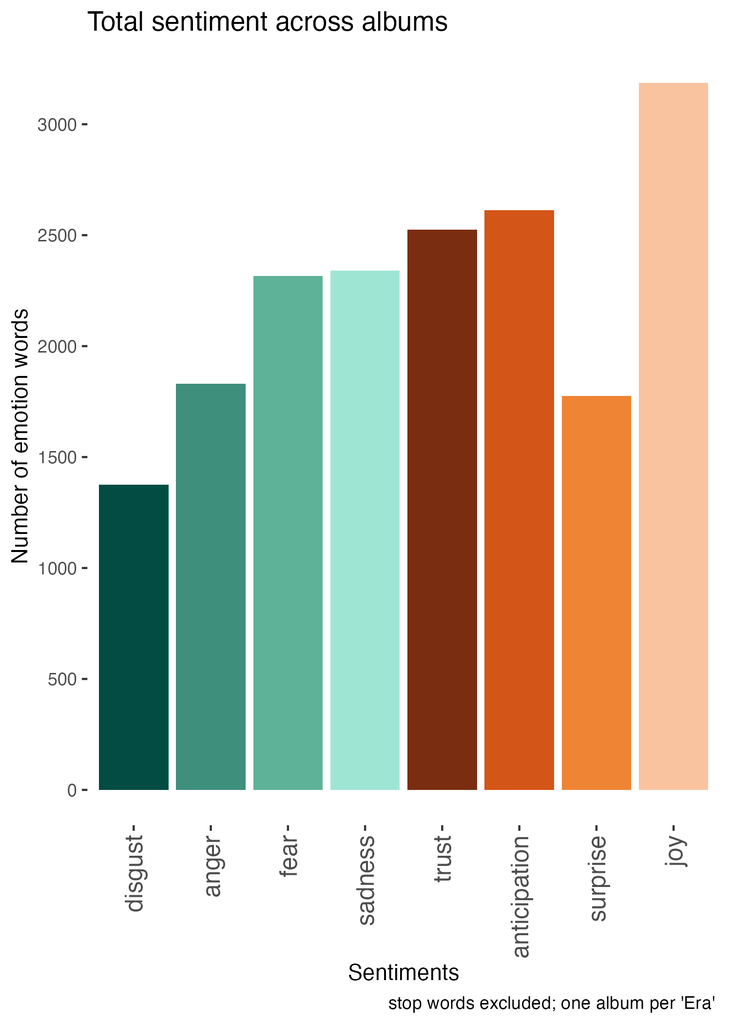

We can better see the difference in the album when comparing it to others in her catalog in the figure below. The album in some ways is much closer to her earlier work from a joy / positive emotion perspective.

Each album is colored by the emotions present with orange representing positive emotions and teal representing negative emotions. The positive emotions present in this album are similar to the earlier work and fall between Midnights and its expanded versions for positive emotions.

## JOY

For Swift, her joy is usually pretty high until folklore. For folklore, evermore, and TTPD (and variants, etc.), joy is about 2/3 of her regular amount. Midnights and Life of a Showgirl are much more in line with the previous amount of joy present. Trust is also pretty high for her, relative to prior work – even compared to Lover (initially thought to be a pretty positive album, but retrospectively thought to be a bit more complex that it appeared on the surface).

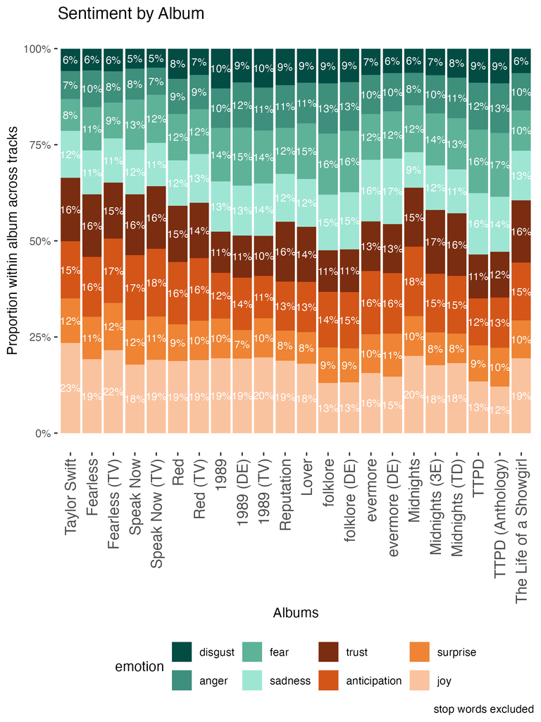

## How does the album compare to her earlier work?

We see that *Showgirl* is quite different from prior albums. It’s in the upper right, between ‘glitter pen’ and ‘Sad, Beautiful, Tragic.’ It raises the question of whether or how this album represents the dawn of a new era.

Note: I did shift the placement of the Sad, Beautiful, Tragic label to try to capture the emotional state a bit better. It might be that a different label would work better here – it seems the songs here are more ‘poignant’ and joyful.

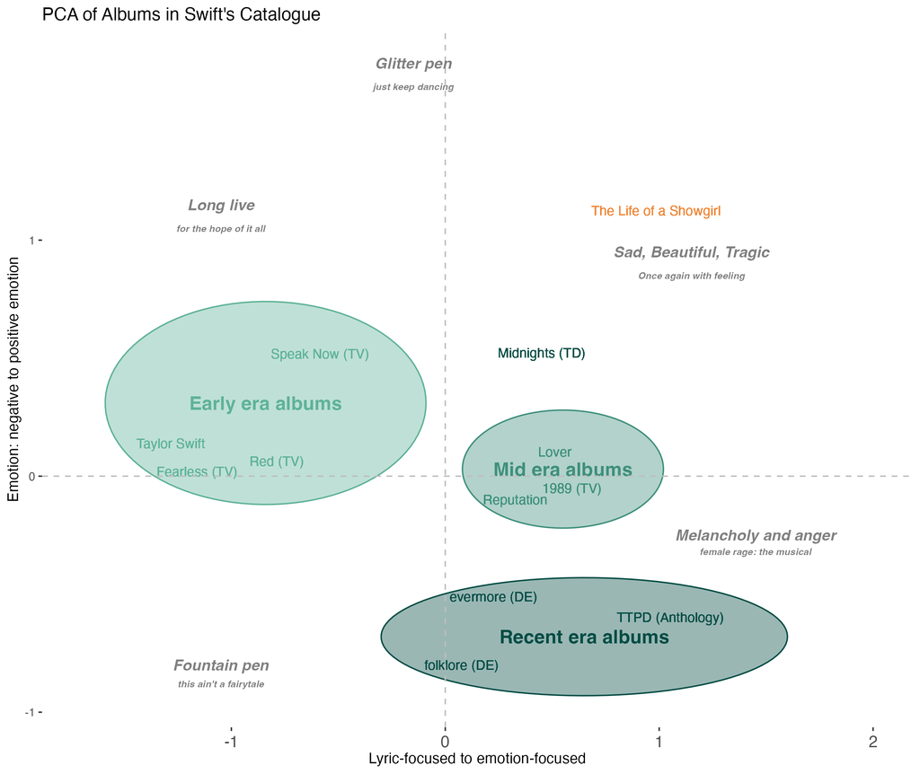

## But what is going on in the album itself?

Here, we look at how the tracks within this two-dimensional space. There are a few really interesting things to notice – primarily the ‘c’ curve of this album. It swoops from the more emotional, to ‘glitter pen’, down through the negative emotions.

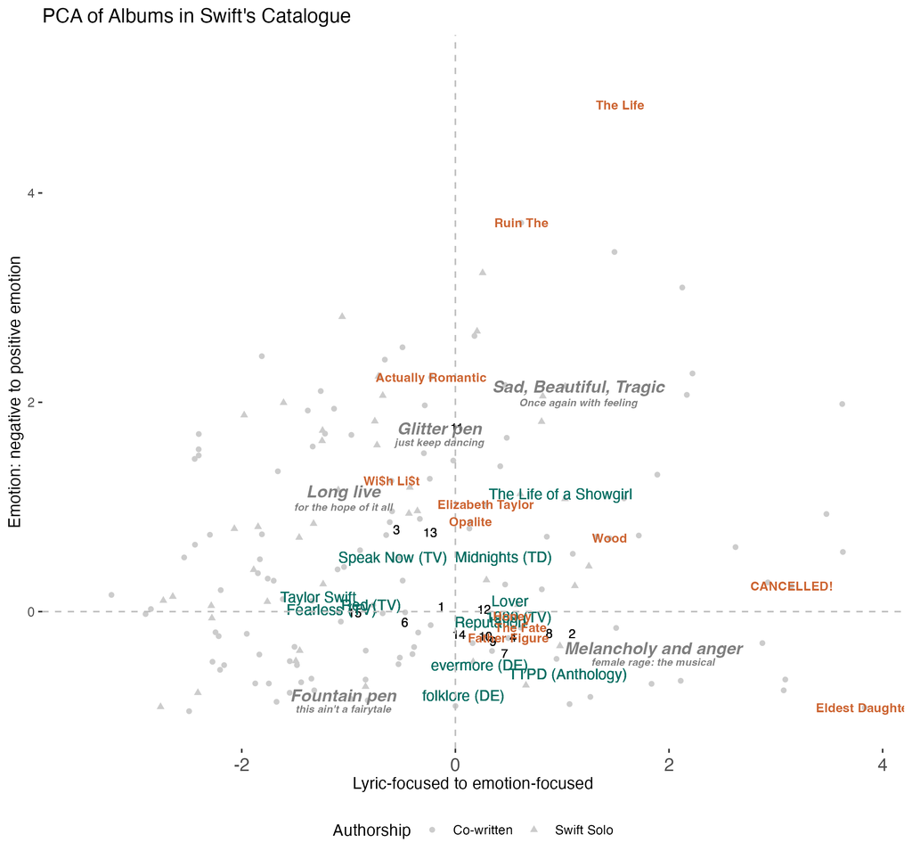

### For fun: each track as an era

Fans have been wondering about how the different tracks connect to or are representative of different albums. I use the above results and my own takes to assign songs to eras.

| Album | Song | Reasoning |
| --- | --- | --- |
| Taylor Swift | Wi$h List | Matches the hopeful, future-forward vibe of the album. |
| Fearless | Elizabeth Taylor | Coming to terms with her new fame and adjusting |
| Speak Now | Actually Romantic | I feel that the spirit behind ‘Dear John’ and writing the whole album solo speaks for this |
| Red | Honey | This is a bit of a bop-but-not and connects to what she was trying to do in Red. Also has some similar vibes to All Too Well |
| 1989 | Opalite | This is a bop and connects with the Max Martin energy |
| Reputation | Cancelled | Similar energy to both the album and the message behind a lot of it |
| Lover | Father Figure | Clear parallels to ‘the man’ |
| Folklore | Fate of Ophelia | Literature connections and storytelling |
| Evermore | Ruin the Friendship | Evermore is an album of more hope, especially anticipation, than it gets credit for. This song is about missed chances and wishing she’d gone for it. |
| Midnights | Wood | Fun, poppy, tongue-in-cheek-and-elsewhere |
| TTPD | Eldest daughter | Oh the angst here. So emotional! |
| The Life of a Showgirl | The Life of a Showgirl | Pretty clear meta thesis re: overall life and her existence |

# Concluding thoughts (for now!)

This album is great (I am also completely biased and inclined to like most of her work) and surprising for many fans. Cancelled was such a great song, although honestly the first half of the album was so strong. I plan to look more into individual songs after I get some rest and a few more listens in.